# FEH statistical analysis

## Peaks over threshold

A peaks over threshold (POT) series can also be obtained from a time series using the `POTextract()` function. A daily sample of the Thames at Kingston flow is included in the package for example purposes (the data frame `ThamesPQ`). The `POTextract()` function can be used on a single vector or a data frame, with dates in the first column and the time series of interest in the second. In the `ThamesPQ` data frame, the Thames flow is in the third column and the date in the first. Therefore, the POT series can be extracted as follows:

```r
# Extract a POT series from the Thames at Kingston daily mean flow data, selecting
# the first and third columns from the ThamesPQ data frame which contain the date
# and flow data respectively. The threshold is set as the 90th percentile.
POT.Thames <- POTextract(ThamesPQ[, c(1, 3)], thresh = 0.9)
```

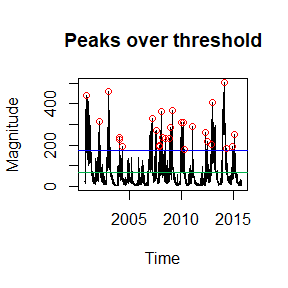

```
#> [1] "Peaks per year: 1.867263"

# View the output
POT.Thames
#>           Date  peak
#> 3   2000-11-07 440.0
#> 25  2002-02-05 316.0
#> 34  2003-01-02 461.0
#> 40  2004-01-13 227.0
#> 41  2004-02-02 238.0
#> 43  2004-05-05 194.0
#> 56  2007-03-07 330.0
#> 58  2007-07-26 274.0
#> 59  2007-11-20 196.0
#> 62  2007-12-09 201.0
```

[output cut: 18 more lines]

This produces a figure showing the daily mean flow data with peaks over the threshold shown as red circles. The blue line is the threshold, and the green line is the mean flow. Independent peaks are chosen above the threshold. If peaks are separated by a drop below the mean flow (green line), they are considered independent. More details can be found in the function’s help file (including other options for defining independence and how to rename axis labels and the plot title).

Note that you can also use the `POTt()` function for extracting peaks over threshold. It works significantly faster, but only has the option of separating peaks by the number of timesteps.

The POT approach is similar to the AMAX approach, except that we need to convert from the POT RP scale to the annual RP scale. To do so, the functions have a peaks per year (ppy) argument. The `POTextract()` function provides the number of peaks per year (in this case, 1.867). To estimate the associated 100-year daily mean flow peak, the GenPareto function can be used as follows:

```r
# Estimate the 100-year flow for the Thames at Kingston using the extracted POT series
GenParetoPOT(POT.Thames$peak, ppy = 1.867, RP = 100)
```

```
#> [1] 605.432
```

## Uncertainty

Methods for quantifying aleatoric (sampling) uncertainty are provided here for three estimation methods: single-site, gauged pooling, and ungauged pooling. The uncertainty is predicated on forming a sampling distribution for the statistic of interest, and in the three cases (single site, gauged pooling, and ungauged pooling), it is done using bootstrapping. In the pooling approaches (gauged and ungauged), the whole pooling group is bootstrapped, and the weighted estimates provided on every iteration.

### Single-site

Extract an annual maximum sample with the following code.

```r
# Extract the AMAX for NRFA site 55002
AM.55002 <- GetAM(55002)
```

The uncertainty for the 100-year flow can be estimated using the `Bootstrap()` function. The 95% confidence intervals are provided by default, but this can be adjusted using the `Conf` argument. The lower limit is provided in the ‘Lower’ column and the upper limit in the ‘Upper’ column.

Note that the `Bootstrap()` function can also be applied for any function/statistic, and the sampling distribution developed can be returned.

```r
# Estimate uncertainty for the GEV-estimated 100-year flow
Bootstrap(AM.55002$Flow, Stat = GEVAM, RP = 100)
```

```
#>   Mean Lower Upper
#> 1  713   622   825
```

### Ungauged pooling

The `Uncertainty()` function can be used for the pooled estimates to quantify the sampling uncertainty. The estimated QMED and the pooling group are required. Furthermore, the factorial standard error needs to be provided for the ungauged case, using the `fseQMED` argument (the default is 1.5). Note that by default the generalised logistic distribution is selected for the estimates, but this can be changed.

The following example to estimate uncertainty for the ungauged pooled estimates for NRFA site 55002 uses the catchment descriptors object created earlier (`CDs.55002`). This provides a dataframe with return period in the first column and Factorial Standard Error (FSE) in the second. For confidence intervals you can divide and multiply your estimates for each return period by the FSE. For 95% intervals do the same but raise the FSE to the power of 1.96.

```r
# Estimate QMED for site 55002 from catchment descriptors using two donors
QMEDEst <- QMED(CDs.55002, DonorIDs = c(55007, 55016))

# Create an ungauged pooling group for site 55002
PoolUG.55002 <- Pool(CDs.55002, exclude = 55002)

# Estimate the uncertainty of the pooling results
Uncertainty(PoolUG.55002, QMEDEstimate = QMEDEst)
```

```
#>      RP    FSE
#> 1     2 1.5000
#> 2     5 1.5121
#> 3    10 1.5307
#> 4    20 1.5573
#> 5    30 1.5767
#> 6    50 1.6055
#> 7    75 1.6319
#> 8   100 1.6525
#> 9   200 1.7087
#> 10  500 1.7974
#> 11 1000 1.8755
```

### Gauged pooling

The gauged case is similar to the above, but the `Gauged` argument is set to `TRUE`, and there is no need to set `QMEDEstimate`; it is derived from the observed AMAX if `Gauged = TRUE`.

It is important to note that when `Gauged` equals `TRUE`, the top site in the pooling group is assumed to be the “gauged” site of interest. This will happen by default because the similarity distance measure should be zero - assuming the that “gauged” site is within the `NRFAData` data frame.

The following example uses the gauged pooling group we previously derived:

```r
# Create a gauged pooling group for site 55002
Pool.55002 <- Pool(CDs = CDs.55002, exclude = c(8010, 76017))

# Estimate the uncertainty of the pooling results
Uncertainty(Pool.55002, Gauged = TRUE)
```

```
#>      RP    FSE
#> 1     2 1.0576
#> 2     5 1.0599
#> 3    10 1.0634
#> 4    20 1.0685
#> 5    30 1.0721
#> 6    50 1.0775
#> 7    75 1.0824
#> 8   100 1.0862
#> 9   200 1.0963
#> 10  500 1.1116
#> 11 1000 1.1247
```

## Exporting results

For use outside of ‘R’, outputs can be saved as objects and then written to CSV files. For example, to save the peak flow estimates from earlier:

```r
# Save the peak flow estimates to an object called 'Results.55002'
Results.55002 <- PoolEst(PoolUG.55002, QMED = CDsQmed.55002)[[1]]

# Write to csv
write.csv(Results.55002, "my/file/path/Results55002.csv", row.names = FALSE)
```